# simPop

2026-07-27

# Packages

```r
library(simPop)
library(tidyverse)

# Only needed for the alternative propensity-score models further down, which
# are commented out by default. rpart is a recommended package and ships with
# R; randomForest has to be installed separately.
library(rpart)
library(randomForest)
```

# Data

The example uses `eusilc13puf`. Despite the “puf” in the name this is **not** a public-use file of real microdata – the help page is titled *“Synthetic EU-SILC 2013 survey data”* and states it was itself synthetically generated from the real Austrian EU-SILC 2013 sample provided by Statistics Austria. 13 513 persons in 5 977 households, 62 of the original survey’s variables simulated.

Two consequences worth stating out loud rather than discovering later:

- We are generating synthetic data **from synthetic data**. Everything below is a valid demonstration of the *method*, but no real person is involved – which matters most for the inference attack at the end.
- The help page claims the sample weights “do not reflect the true population sizes of Austria and its regions”. That is boilerplate shared with the other example datasets and it is **not true of the weight we actually use** (see below).

Eleven variables are kept: the household identifier and size, region, the three demographics, economic status, citizenship, personal and household gross income, and the sampling weight.

A trap in that last one. The column literally named `weight` in `eusilc13puf` is **all 1s** – it is there for the “treat this file as if it were already a population” case. The weight this document uses is column 46, `rb050`, the official EU-SILC personal cross-sectional weight, which is then *renamed* to `weight`. And `rb050` is a real weight: it sums to 8 332 260, i.e. 98% of Austria’s 2013 population, and its regional totals match the actual federal states.

It has been flattened, though: only **9 distinct values, one per region**. Real EU-SILC weights are calibrated per household to age and sex margins as well. Here every person in a region carries the same weight, so what we have are regional design weights and nothing more.

```r
data(eusilc13puf, package = "simPop")
# ??eusilc13puf

df <- eusilc13puf[,c(1:6, 8:9,14, 16, 46)]
df$age <- as.numeric(df$age)
df$pid <- as.factor(df$pid)


vars <- c("hhid", "hsize", "region", "age", "sex", "pid", "eco_stat", "citizenship",
          "pgrossIncome","hgrossIncome","weight")

colnames(df) <- vars

# simPop's models cannot take NA as a predictor level, so missing values get an
# explicit category. Note this is a modelling convenience, not a neutral act:
# "Unknown" becomes a real category that the multinomial models will happily
# predict for synthetic people, and it is large -- about 23% of all persons.
df$eco_stat <- as.character(df$eco_stat)
df$eco_stat[is.na(df$eco_stat)] <- "Unknown"
df$eco_stat <- factor(df$eco_stat)
df$citizenship <- as.character(df$citizenship)
df$citizenship[is.na(df$citizenship)] <- "Unknown"
df$citizenship <- factor(df$citizenship)

# A missing personal income is treated as zero income. Defensible here (most
# NAs are people outside the labour market) but it is an assumption, and it is
# what makes ~24% of the target variable exactly 0 -- which matters later when
# we model it as semi-continuous.
df$pgrossIncome[is.na(df$pgrossIncome)] <- 0

# CAREFUL: rb050 grosses up to 8.33m, i.e. essentially Austria. Dividing by 100
# shrinks the generated population to ~83k persons purely to keep the runtime of
# this demo bearable, and it means every absolute count from here on is 100x too
# small. Multiply by 100 to read them, or drop this line for a real run.
df$weight <- df$weight / 100

# see data
head(df, 10)
```

```
##    hhid hsize region age    sex   pid eco_stat citizenship pgrossIncome
## 1    30     1   AT11  93 female  30.1  Unknown     Unknown         0.00
## 2    53     1   AT11  55   male  53.1        1          AT     27306.75
## 3   168     1   AT11  59 female 168.1        2          AT     22794.10
## 4   296     1   AT11  93 female 296.1  Unknown     Unknown         0.00
## 5   317     1   AT11  31   male 317.1        1          AT     37470.10
## 6   337     1   AT11  68   male 337.1        1          AT         0.00
## 7   438     1   AT11  38   male 438.1        1          AT     35521.92
## 8   576     1   AT11  38   male 576.1        1          AT     30000.64
## 9   747     1   AT11  72 female 747.1        1          AT      4085.42
## 10  799     1   AT11  81   male 799.1        1          AT         0.00
##    hgrossIncome weight
## 1      55.56062  5.756
## 2    1448.68990  5.756
## 3     416.08898  5.756
## 4      62.75806  5.756
## 5     128.94705  5.756
## 6   10499.81635  5.756
## 7     161.36377  5.756
## 8     198.11045  5.756
## 9   10878.72254  5.756
## 10     86.89371  5.756
```

# Synthesis

## Define input

It is necessary to identify in the microdata which variables provide information on clustering, household size, subpopulations, and sampling weights. The sample weights can be calibrated by iterative proportional fitting to the population totals.

```r
inp <-
  specifyInput(
    data = df,
    hhid = "hhid",
    hhsize = "hsize",
    strata = "region",
    weight = "weight",
    population = FALSE
  )
```

```r
# Calibrate sample weights
# data("totalsRG", package = "simPop")
# totalsRG <- totalsRG |> rename(sex = rb090, region = db040)
# print(totalsRG)
# totalsRG$Freq <- totalsRG$Freq / 100
# addWeights(inp) <- calibSample(inp, totalsRG)
```

## Define structure

The household structure of the synthetic population is created by extrapolating the sample using the sample weights/calibrated weights and re-sampling (alias sampling) when method = “distribution” (if one does not wish to create a population, one should use sample weights = 1 as a variable in one’s data). For this process, the household structure must contain a set of user-defined “basicHHvars”. In this case, we use age, sex, and region. Other methods may be selected, such as “direct,” which employs the Horvitz-Thompson estimator to estimate the population totals for each combination of stratum and household size. Alternatively, “multinom” may be utilized to estimate the conditional probabilities within the strata using a multinomial log-linear model and random draws from the resulting distribution.

**All values accepted by `method` in `simStructure()`:**

| `method` | what it does |
| --- | --- |
| `"distribution"` | *used here.* Alias sampling: estimates how many households of each size belong in each stratum, then resamples that many whole households from the sample. |
| `"direct"` | Horvitz-Thompson estimation of the population totals for every stratum × household-size combination. |
| `"multinom"` | Multinomial log-linear model for the conditional probabilities within strata, followed by random draws. |

```r
simPop <-
  simStructure(
    data = inp,
    method = "distribution", # direct
    basicHHvars = c("age", "sex", "region"),
    seed = SEED
  )
```

## Define categorical variables

Categorical variables are simulated using the defined household structure and the weights as an input. The package offers two methodological approaches to add/simulate the categorical variables: one is a model-based simulation, the other a synthetic reconstruction. In this example, we utilize the model-based simulation. A multinomial model is fit to sample data, so that the categorical variable to be simulated is the response variable and the other defined household variables serve as predictors. Subsequently, the model employs the conditional probabilities to “predict” the manifestation of the selected variable. In our example, we generate categorical variable economic status and citizenship.

In addition to the “multinom” argument method, which entails the estimation of conditional probabilities using multinomial log-linear models and random draws from the resulting distributions, several other methods are accepted.

**All values accepted by `method` in `simCategorical()`:**

[output not shown]

All of these are ready to use – `partykit`, `ranger` and `xgboost` are hard dependencies of simPop, not optional extras, so nothing needs installing.

Switching method is a one-word edit, which makes this a good place to stop and try one: `"ctree"` on the same two variables takes seconds and its results can be compared against the multinomial fit using exactly the utility measures further down.

```r
simPop <-
  simCategorical(
    simPop,
    additional = c("eco_stat", "citizenship"),
    method = "multinom",
    seed = SEED
  )
```

## Define continuous variables

It is recommended that continuous variables be defined after categorical variables, as the continuous variables are added to the structure using a modeling approach. This approach allows for the simulated categorical variables to be accounted for when simulating the continuous ones. There are several approaches to simulate continuous variables in simPop. The default approach is based on the same methodology as the simulation of the categorical variables, described above. The continuous variable is categorized (using quantiles as the default) and the multinomial model is estimated. In the final step, random draws are taken from the intervals of the categories into which the predictions at the population level fall. An alternative approach is the “lm” method, which is based on a two-step regression model with random error terms. This method involves first fitting a logistic regression model and then a linear regression model. This is necessary when considering semi-continuous distributions, as otherwise only the linear regression imputation is applied. The other methods are Poisson for count variables and xgboost.

**All values accepted by `method` in `simContinuous()`:**

[output not shown]

Note that the choice interacts with the shape of the variable rather than being free. Personal gross income is 24% zeros, so `"lm"` with `zeros = TRUE` is the natural fit; household gross income has no such spike and is handled below with `"multinom"`. Both calls appear in this document precisely so the two can be compared.

In this example, we will simulate the personal gross income, a semi-continuous variable, using the “lm” method with the two-step regression and the household income with the “multinom” method, a multinomial model.

```r
# nr_cpus = 1 turns off simPop's parallelisation. Counter-intuitively this makes
# the whole document about twice as fast -- this step alone drops from roughly
# 20 seconds to under one, because at this data size the cost of starting and
# feeding the workers dwarfs the work itself. Worth knowing before running it
# in front of an audience.
#
# Note how thin the model is: personal income is explained by sex and household
# size only. The richer specification is commented out on the next line. This
# keeps the demo fast, but it is also the reason the income distribution is
# reproduced far less convincingly than the categorical variables were -- worth
# coming back to when we measure utility below.
simPop <- simContinuous(
  simPop,
  method = "lm",
  additional = "pgrossIncome",
  regModel = ~ sex + hsize, #+ eco_stat + citizenship + age,
  zeros = TRUE,
  log = FALSE,
  #const = 1,
  alpha = NULL, #0.05,
  residuals = TRUE,
  seed = SEED,   # without this, simContinuous() does not seed at all
  nr_cpus = 1
)
```

```r
simPop <- simContinuous(
  simPop,
  method = "multinom",
  additional = "hgrossIncome",
  regModel = ~ sex + hsize + eco_stat + citizenship + pgrossIncome + I(pgrossIncome^2),
  # With parallelisation off this becomes the slowest step of the document,
  # around 8 seconds -- still half of what the two steps cost together before.
  upper = 200000,
  equidist = FALSE,
  nr_cpus = 1,
  seed = SEED
)
```

## Simulation of components

In household surveys, information on net individual income is typically not collected, but derived from other variables (e.g., from information collected on income by source). A synthetically generated continuous variable can be broken down by its components using function simComponents().The simulation of components of continuous variables of population data is performed by resampling fractions using the survey data at hand. We do not have such component data in our dataset but below a code snippet of how to define the function.

```r
# simPop <- simComponents(
#   simPop,
#   total = "pgrossIncome",
#   components = c(
#     "py010g", # Employee cash or near cash income
#     "py021g", # Company car
#     "py050g", # Cash benefits or losses from self-employment
#     "py080g", # Pension from individual private plans
#     "py090g", # Unemployment benefits
#     "py100g", # Old-age benefits
#     "py110g", # Survivor’ benefits
#     "py120g", # Sickness benefits
#     "py130g", # Disability benefits
#     "py140g"  # Education-related allowances
#   ),
#   conditional = c("economic_status","citizenship","sex"), # check what is best
#   replaceEmpty = c("sequential", "min"),
#   seed = 1
# )
```

## Post-calibration of the synthetic population

Although the sample used as input for the simulation of the synthetic population had been calibrated to known marginals, the resulting population will not exactly match these marginals due to the randomness in the data generation process. If a (quasi) perfect match to the known marginals is a requirement the function `calibPop()` can be applied. It uses simulated annealing – the combinatorial-optimization approach – to swap households between groups until the known margins are matched, so it is a post-processing step on an already generated population, not an alternative way of generating one. It is not run here: it takes considerably longer than everything above put together.

# Data utility

## Univariate and multivariate distributions

```r
data_sample <- data.frame(sampleData(simPop))
data_pop <- data.frame(popData(simPop))

tableWt(data_sample$citizenship, weights = data_sample$weight)
```

```
## x
##      AT      EU   Other Unknown
##   57082    2969    4313   18959
```

```r
table(data_pop$citizenship)
```

```
##
##      AT      EU   Other Unknown
##   56896    2962    4349   19024
```

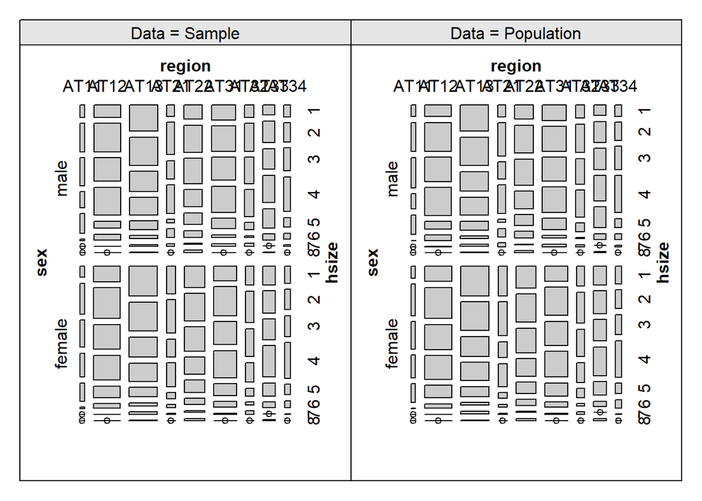

Mosaic plots of gender, region and household size

```r
tab <- spTable(simPop, select = c("sex", "region", "hsize"))
spMosaic(tab, labeling = labeling_border(abbreviate = c(region = TRUE)))
```

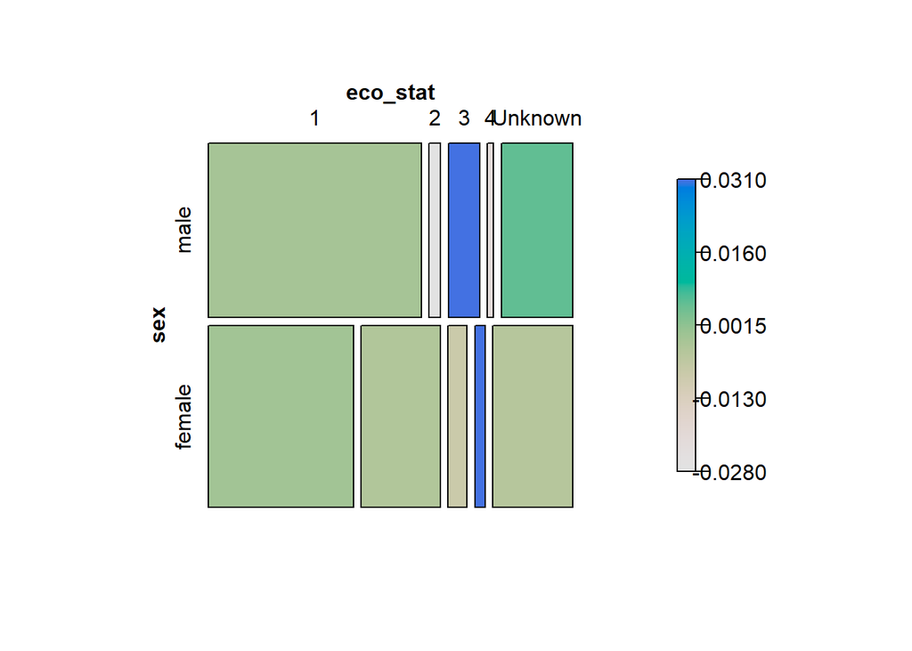

```r
tab <- spTable(simPop, select = c("sex", "eco_stat"))
spMosaic(tab, method = "color")
```

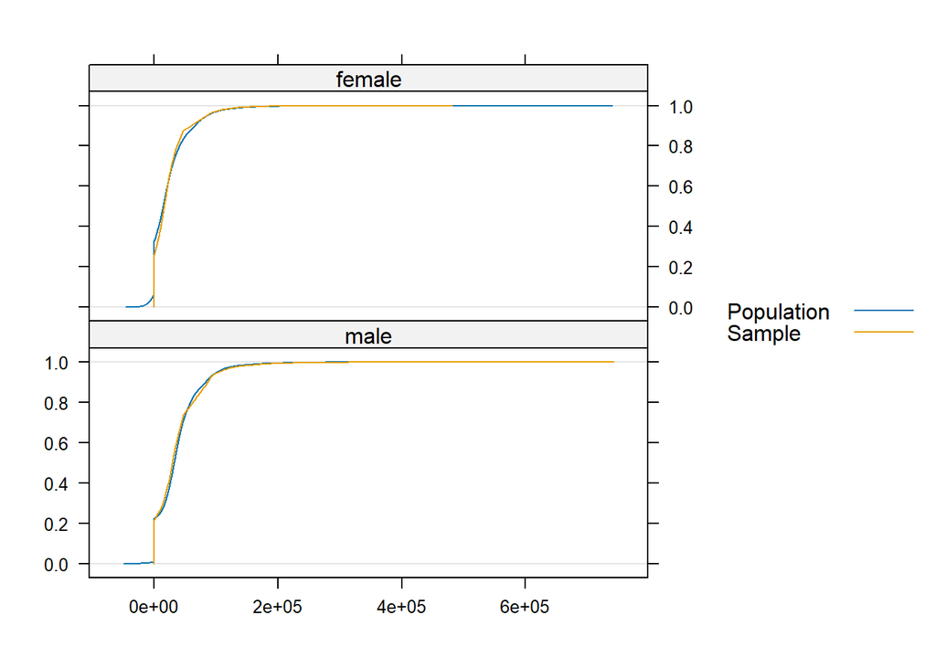

CDF pgross income

```r
spCdfplot(simPop, "pgrossIncome", cond = "sex", layout = c(1, 2)
          )
```

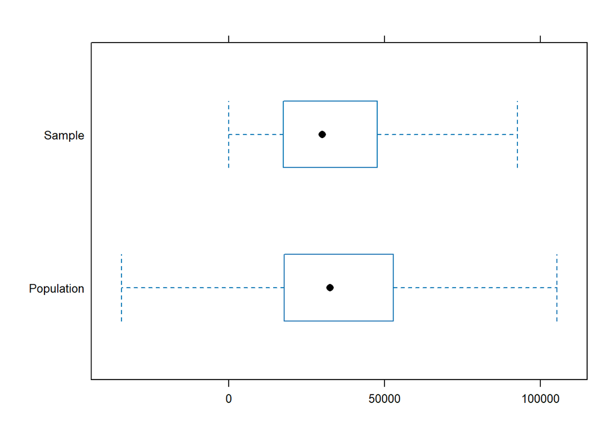

Boxplot pgross income

```r
spBwplot(simPop, x = "pgrossIncome", #cond = "pgrossIncome", layout = c(1, 2)
         )
```

## Data utility with model fitting

### Propensity Scores

The measures above compare one distribution at a time. A propensity score judges the whole dataset at once, by turning “are these two datasets alike?” into a prediction problem: stack the real sample on top of the synthetic population, label which row came from where, and try to train a model that tells them apart. If a reasonable model cannot separate them, the two are distributionally similar. The density plot is the actual result to look at – two overlapping humps mean the model is guessing.

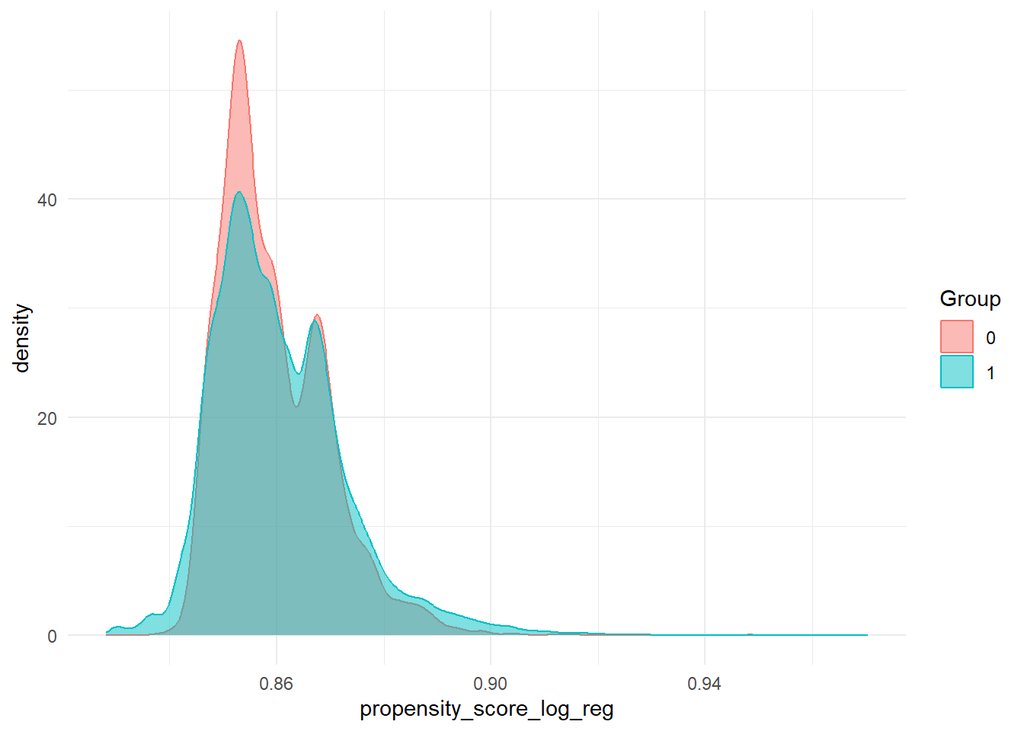

```r
data_sample$group <- 0   # real sample
data_pop$group    <- 1   # synthetic population

combined_data <- rbind(data_sample , data_pop |> dplyr::select(-hgrossIncomeCat))

res_logreg <- glm(
  group ~ region + hsize + eco_stat  +  sex + citizenship + pgrossIncome + hgrossIncome ,
  data = combined_data,
  family = binomial()
)

# Optional alternatives. A tree and a forest pick up interactions that the
# additive logistic model cannot see, so they are the stricter test -- if the
# forest separates the two sources while the logistic model does not, the
# similarity was only marginal. Both need the libraries loaded at the top.
# res_cart <- rpart(
#   group ~ region + hsize + eco_stat + sex + citizenship + pgrossIncome + hgrossIncome,
#   data = combined_data,
#   method = "class",
#   control = rpart.control(minsplit = 5, cp = 0.001, maxdepth = 30)
# )
# res_rf <- randomForest(
#   group ~ region + hsize + eco_stat  +  sex + citizenship + pgrossIncome + hgrossIncome,
#   data = combined_data,
#   ntree = 10,
#   importance = TRUE
#   )

combined_data <- combined_data |> mutate(
  propensity_score_log_reg = predict(res_logreg, type = "response"),
  # propensity_score_CART    = predict(res_cart, type = "prob")[,2]
  # propensity_score_rf = predict(res_rf, type = "response")
  )


ggplot(combined_data, aes(x = propensity_score_log_reg, color = as.factor(group), fill = as.factor(group))) +
  geom_density(alpha = 0.5) +
  labs(color = "Group", fill = "Group") +
  theme_minimal()
```

Two things have to be said before any number from this is quoted.

**The groups are nowhere near equal in size** – about 13.5k real records against 83k synthetic ones. A classifier scores well here simply by answering “synthetic” every time, so the reference point cannot be 1/2. It has to be `c`, the share of synthetic records, which is the propensity every row would receive if the two sources were truly indistinguishable.

**pMSE and the Brier score point in opposite directions.** pMSE measures distance from `c`: small means the model cannot tell the sources apart, so *small is good*. The Brier score measures how well the model predicts actual membership, so *small is bad* – it means the two sources separate cleanly. Confusing the two inverts the conclusion, which is why both are printed here with their direction spelled out.

```r
c_ref <- mean(combined_data$group)   # share of synthetic records

# pMSE (cf. Woo et al. 2009): squared distance of each propensity from the value
# expected under "no difference between the datasets". SMALL = GOOD utility.
pmse <- mean((combined_data$propensity_score_log_reg - c_ref)^2)

# Brier score: accuracy of predicting actual membership. SMALL = BAD utility,
# because it means the model separates real from synthetic.
brier <- mean((combined_data$propensity_score_log_reg - combined_data$group)^2)

# A model that learned nothing and always answers c scores exactly c(1-c).
# That is the number the Brier score above has to be read against: anything
# close to it means the covariates carry no usable signal about which dataset a
# row came from.
brier_trivial <- c_ref * (1 - c_ref)

data.frame(
  measure   = c("c (share of synthetic records)",
                "pMSE  -- distance from c",
                "Brier -- accuracy of group prediction",
                "Brier of a trivial 'always guess c' model"),
  value     = round(c(c_ref, pmse, brier, brier_trivial), 5),
  direction = c("--", "smaller is better", "smaller is worse", "reference")
)
```

```
##                                     measure   value         direction
## 1            c (share of synthetic records) 0.86032                --
## 2                  pMSE  -- distance from c 0.00015 smaller is better
## 3     Brier -- accuracy of group prediction 0.12005  smaller is worse
## 4 Brier of a trivial 'always guess c' model 0.12017         reference
```

Snoke *et al.* (2018) standardise pMSE by its variance under the null, which turns it into a scale-free ratio and allows an actual significance test. That is the right thing to do if the number is going to be reported rather than merely looked at; here the density plot carries the message.

A cleaner alternative to worrying about `c` at all is to draw a random subsample of the synthetic population the same size as the real sample. Then `c` is 1/2 by construction, the textbook formula applies unchanged, and the density plot becomes easier to read.

# Confidentiality (inference attack)

**Scenario.** The intruder has complete information on region, household size, age, gender, economic status and citizenship of a person – the *key variables* – and wants to learn that person’s personal gross income, the *confidential variable*. Only the synthetic population has been published; the real sample has not.

The attack is to fit a model for income on the published synthetic data, then apply it to the key variables the intruder already holds, and see how close the prediction lands to the truth.

Note what this does and does not measure. It is an **attribute-disclosure** test: how much can be inferred about a known person’s income. It is *not* re-identification – no records are matched one-to-one and no threshold for a “successful” match is applied anywhere below. Re-identification would be a different exercise, and on fully synthetic data a considerably more awkward one, because a synthetic record does not correspond to any single real person to begin with.

## Predict confidential variable (personal gross income) in the synthetic data

```r
# Define intruder knowledge
intruder_knowledge <- data_sample |> select(-hhid, -pgrossIncome, -hgrossIncome, -weight)
# Write out the true values of income
true_pgrossincome <- data_sample |> select(pgrossIncome, pid)
# Fit a model on the synthetic population for the personal gross income
inf_attack_model <- lm(pgrossIncome ~ sex + hsize + eco_stat + citizenship + age + region, data = data_pop)
```

## Compare the true values to the predicted

```r
intruder_knowledge$predictions = predict(inf_attack_model, newdata = intruder_knowledge)
compare_df<- left_join(intruder_knowledge, true_pgrossincome, by = "pid")
compare_df$result <- abs(compare_df$pgrossIncome - compare_df$predictions)
mean(compare_df$result)
```

```
## [1] 23108
```

## Is that error large or small?

On its own the number above says nothing at all. It is a mean absolute error in euros, and whether it constitutes a privacy failure depends entirely on what it is compared against. Two reference points settle it:

- **A trivial guess.** An intruder who never saw the data and simply always answers “the median income” already achieves some error. If the attack does not clearly beat that, it has extracted essentially nothing.
- **The ceiling.** The same model fitted on the *real* sample is what an intruder holding the true microdata could manage. The attack cannot do better than this, and the gap between the two is exactly what the synthesis destroyed.

```r
y <- compare_df$pgrossIncome
mae <- function(pred) mean(abs(y - pred))

ceiling_model <- lm(pgrossIncome ~ sex + hsize + eco_stat + citizenship + age + region,
                    data = data_sample)

data.frame(
  scenario = c("attack: model fitted on the synthetic population",
               "ceiling: same model fitted on the real sample",
               "baseline: always guess the median",
               "baseline: always guess the mean"),
  MAE = round(c(mae(compare_df$predictions),
                mae(predict(ceiling_model, newdata = data_sample)),
                mae(median(y)),
                mae(mean(y))))
)
```

```
##                                           scenario   MAE
## 1 attack: model fitted on the synthetic population 23108
## 2    ceiling: same model fitted on the real sample 19584
## 3                baseline: always guess the median 23716
## 4                  baseline: always guess the mean 24723
```

The attack lands only marginally better than always guessing the median, and well short of the ceiling. Both halves matter: the first says the published population leaks very little about any individual’s income, the second says the reason is the synthesis itself rather than the income simply being unpredictable.

One caveat against over-claiming from this. The income model in `simContinuous()` above used only `sex` and `hsize`, so income was weakly tied to the key variables in the synthetic data from the start. Part of the privacy protection on display here is therefore a side effect of a deliberately thin model – the same thin model that cost us utility earlier. Utility and disclosure risk are being traded against each other, and this document sits at one particular point on that curve rather than demonstrating a free lunch.